# Project: Investigate a Dataset (Medical Appointments Data in Brazil)

- Introduction
- Data Wrangling
- Exploratory Data Analysis
- Conclusions

## Important Please refer the cell Below once

```python
##Data_size_limit = 110527  ## IT is too big file and takes a lot of processing time hence for testing the code use lesser value

## The Html form of the file has the results executed for all the 110527 rows so refer that for actual result

Data_size_limit  = 5000   ## Taken For now
```

# Introduction

## Dataset taken for analysis :- No-show appointments

- This data contains a lot of information about the patients , their appointments dates and weather they came for the appointment or not.
- The data is collected from the medical appointments in the Brazil

## Questions to be analysed

- **Main focus of the questions is to find out what all factors affect the patients attending the appointments or not**
- **Q1 What is the impact of location of hospitals on the patients attending the appointment or not?**
- **Q2 What is the impact of Age of patients on the patients attending the appointment or not?**
- **Q3 what impact does enrolling into Brasilian welfare program 'Bolsa Família' have on appointments?**
- **Q4 what impact does having a desiease has on appointment**

```python
## Importing the necessary file that will be used throughout the project
import pandas as pd
import numpy as np
import matplotlib.pyplot as plt
import seaborn as sns
import pprint as pp


## Now importing the data into a Pandas Data frame for furthure processing


Appointment_data = pd.read_csv('noshowappointments-kagglev2-may-2016.csv')

## Viewing a snapshot of the data to get some idea about its organisation structure
Appointment_data.head(8)
```

|  | PatientId | AppointmentID | Gender | ScheduledDay | AppointmentDay | Age | Neighbourhood | Scholarship | Hipertension | Diabetes | Alcoholism | Handcap | SMS_received | No-show |
| --- | --- | --- | --- | --- | --- | --- | --- | --- | --- | --- | --- | --- | --- | --- |
| 0 | 2.987250e+13 | 5642903 | F | 2016-04-29T18:38:08Z | 2016-04-29T00:00:00Z | 62 | JARDIM DA PENHA | 0 | 1 | 0 | 0 | 0 | 0 | No |
| 1 | 5.589978e+14 | 5642503 | M | 2016-04-29T16:08:27Z | 2016-04-29T00:00:00Z | 56 | JARDIM DA PENHA | 0 | 0 | 0 | 0 | 0 | 0 | No |
| 2 | 4.262962e+12 | 5642549 | F | 2016-04-29T16:19:04Z | 2016-04-29T00:00:00Z | 62 | MATA DA PRAIA | 0 | 0 | 0 | 0 | 0 | 0 | No |
| 3 | 8.679512e+11 | 5642828 | F | 2016-04-29T17:29:31Z | 2016-04-29T00:00:00Z | 8 | PONTAL DE CAMBURI | 0 | 0 | 0 | 0 | 0 | 0 | No |
| 4 | 8.841186e+12 | 5642494 | F | 2016-04-29T16:07:23Z | 2016-04-29T00:00:00Z | 56 | JARDIM DA PENHA | 0 | 1 | 1 | 0 | 0 | 0 | No |
| 5 | 9.598513e+13 | 5626772 | F | 2016-04-27T08:36:51Z | 2016-04-29T00:00:00Z | 76 | REPÚBLICA | 0 | 1 | 0 | 0 | 0 | 0 | No |
| 6 | 7.336882e+14 | 5630279 | F | 2016-04-27T15:05:12Z | 2016-04-29T00:00:00Z | 23 | GOIABEIRAS | 0 | 0 | 0 | 0 | 0 | 0 | Yes |
| 7 | 3.449833e+12 | 5630575 | F | 2016-04-27T15:39:58Z | 2016-04-29T00:00:00Z | 39 | GOIABEIRAS | 0 | 0 | 0 | 0 | 0 | 0 | Yes |

# Data Wrangling

## General Properties of Data

- The data consist of information regarding the **appointment schedule of the patients and also keeps track of their appointment attendance**.
- Along with this the data consist of basic information such as **age , sex , location of the hospital**.
- The data also keeps track of the following parameters **Scholarship,Hipertension , Diabetes , Alcoholism Handcap SMS_received**
- Peculiarity of the data is in the encoding of the last column: **it says ‘No’ if the patient showed up to their appointment, and ‘Yes’ if they did not show up**.

```python
## Studying the Basic Statistics of the project

 ## displaying basic statistical information of the raw data using pandas describe() feature

Appointment_data.describe()
```

|  | PatientId | AppointmentID | Age | Scholarship | Hipertension | Diabetes | Alcoholism | Handcap | SMS_received |
| --- | --- | --- | --- | --- | --- | --- | --- | --- | --- |
| count | 1.105270e+05 | 1.105270e+05 | 110527.000000 | 110527.000000 | 110527.000000 | 110527.000000 | 110527.000000 | 110527.000000 | 110527.000000 |
| mean | 1.474963e+14 | 5.675305e+06 | 37.088874 | 0.098266 | 0.197246 | 0.071865 | 0.030400 | 0.022248 | 0.321026 |
| std | 2.560949e+14 | 7.129575e+04 | 23.110205 | 0.297675 | 0.397921 | 0.258265 | 0.171686 | 0.161543 | 0.466873 |
| min | 3.921784e+04 | 5.030230e+06 | -1.000000 | 0.000000 | 0.000000 | 0.000000 | 0.000000 | 0.000000 | 0.000000 |
| 25% | 4.172614e+12 | 5.640286e+06 | 18.000000 | 0.000000 | 0.000000 | 0.000000 | 0.000000 | 0.000000 | 0.000000 |
| 50% | 3.173184e+13 | 5.680573e+06 | 37.000000 | 0.000000 | 0.000000 | 0.000000 | 0.000000 | 0.000000 | 0.000000 |
| 75% | 9.439172e+13 | 5.725524e+06 | 55.000000 | 0.000000 | 0.000000 | 0.000000 | 0.000000 | 0.000000 | 1.000000 |
| max | 9.999816e+14 | 5.790484e+06 | 115.000000 | 1.000000 | 1.000000 | 1.000000 | 1.000000 | 4.000000 | 1.000000 |

```python
## Analysing the structure of the data

## Viewing a sample of data to check of some major inconsistency in it

Appointment_data.head(40)
```

|  | PatientId | AppointmentID | Gender | ScheduledDay | AppointmentDay | Age | Neighbourhood | Scholarship | Hipertension | Diabetes | Alcoholism | Handcap | SMS_received | No-show |
| --- | --- | --- | --- | --- | --- | --- | --- | --- | --- | --- | --- | --- | --- | --- |
| 0 | 2.987250e+13 | 5642903 | F | 2016-04-29T18:38:08Z | 2016-04-29T00:00:00Z | 62 | JARDIM DA PENHA | 0 | 1 | 0 | 0 | 0 | 0 | No |
| 1 | 5.589978e+14 | 5642503 | M | 2016-04-29T16:08:27Z | 2016-04-29T00:00:00Z | 56 | JARDIM DA PENHA | 0 | 0 | 0 | 0 | 0 | 0 | No |
| 2 | 4.262962e+12 | 5642549 | F | 2016-04-29T16:19:04Z | 2016-04-29T00:00:00Z | 62 | MATA DA PRAIA | 0 | 0 | 0 | 0 | 0 | 0 | No |
| 3 | 8.679512e+11 | 5642828 | F | 2016-04-29T17:29:31Z | 2016-04-29T00:00:00Z | 8 | PONTAL DE CAMBURI | 0 | 0 | 0 | 0 | 0 | 0 | No |
| 4 | 8.841186e+12 | 5642494 | F | 2016-04-29T16:07:23Z | 2016-04-29T00:00:00Z | 56 | JARDIM DA PENHA | 0 | 1 | 1 | 0 | 0 | 0 | No |
| 5 | 9.598513e+13 | 5626772 | F | 2016-04-27T08:36:51Z | 2016-04-29T00:00:00Z | 76 | REPÚBLICA | 0 | 1 | 0 | 0 | 0 | 0 | No |
| 6 | 7.336882e+14 | 5630279 | F | 2016-04-27T15:05:12Z | 2016-04-29T00:00:00Z | 23 | GOIABEIRAS | 0 | 0 | 0 | 0 | 0 | 0 | Yes |
| 7 | 3.449833e+12 | 5630575 | F | 2016-04-27T15:39:58Z | 2016-04-29T00:00:00Z | 39 | GOIABEIRAS | 0 | 0 | 0 | 0 | 0 | 0 | Yes |
| 8 | 5.639473e+13 | 5638447 | F | 2016-04-29T08:02:16Z | 2016-04-29T00:00:00Z | 21 | ANDORINHAS | 0 | 0 | 0 | 0 | 0 | 0 | No |
| 9 | 7.812456e+13 | 5629123 | F | 2016-04-27T12:48:25Z | 2016-04-29T00:00:00Z | 19 | CONQUISTA | 0 | 0 | 0 | 0 | 0 | 0 | No |
| 10 | 7.345362e+14 | 5630213 | F | 2016-04-27T14:58:11Z | 2016-04-29T00:00:00Z | 30 | NOVA PALESTINA | 0 | 0 | 0 | 0 | 0 | 0 | No |
| 11 | 7.542951e+12 | 5620163 | M | 2016-04-26T08:44:12Z | 2016-04-29T00:00:00Z | 29 | NOVA PALESTINA | 0 | 0 | 0 | 0 | 0 | 1 | Yes |
| 12 | 5.666548e+14 | 5634718 | F | 2016-04-28T11:33:51Z | 2016-04-29T00:00:00Z | 22 | NOVA PALESTINA | 1 | 0 | 0 | 0 | 0 | 0 | No |
| 13 | 9.113946e+14 | 5636249 | M | 2016-04-28T14:52:07Z | 2016-04-29T00:00:00Z | 28 | NOVA PALESTINA | 0 | 0 | 0 | 0 | 0 | 0 | No |
| 14 | 9.988472e+13 | 5633951 | F | 2016-04-28T10:06:24Z | 2016-04-29T00:00:00Z | 54 | NOVA PALESTINA | 0 | 0 | 0 | 0 | 0 | 0 | No |
| 15 | 9.994839e+10 | 5620206 | F | 2016-04-26T08:47:27Z | 2016-04-29T00:00:00Z | 15 | NOVA PALESTINA | 0 | 0 | 0 | 0 | 0 | 1 | No |
| 16 | 8.457439e+13 | 5633121 | M | 2016-04-28T08:51:47Z | 2016-04-29T00:00:00Z | 50 | NOVA PALESTINA | 0 | 0 | 0 | 0 | 0 | 0 | No |
| 17 | 1.479497e+13 | 5633460 | F | 2016-04-28T09:28:57Z | 2016-04-29T00:00:00Z | 40 | CONQUISTA | 1 | 0 | 0 | 0 | 0 | 0 | Yes |
| 18 | 1.713538e+13 | 5621836 | F | 2016-04-26T10:54:18Z | 2016-04-29T00:00:00Z | 30 | NOVA PALESTINA | 1 | 0 | 0 | 0 | 0 | 1 | No |
| 19 | 7.223289e+12 | 5640433 | F | 2016-04-29T10:43:14Z | 2016-04-29T00:00:00Z | 46 | DA PENHA | 0 | 0 | 0 | 0 | 0 | 0 | No |
| 20 | 6.222575e+14 | 5626083 | F | 2016-04-27T07:51:14Z | 2016-04-29T00:00:00Z | 30 | NOVA PALESTINA | 0 | 0 | 0 | 0 | 0 | 0 | Yes |
| 21 | 1.215484e+13 | 5628338 | F | 2016-04-27T10:50:45Z | 2016-04-29T00:00:00Z | 4 | CONQUISTA | 0 | 0 | 0 | 0 | 0 | 0 | Yes |
| 22 | 8.632298e+14 | 5616091 | M | 2016-04-25T13:29:16Z | 2016-04-29T00:00:00Z | 13 | CONQUISTA | 0 | 0 | 0 | 0 | 0 | 1 | Yes |
| 23 | 2.137540e+14 | 5634142 | F | 2016-04-28T10:27:05Z | 2016-04-29T00:00:00Z | 46 | CONQUISTA | 0 | 0 | 0 | 0 | 0 | 0 | No |
| 24 | 8.734858e+12 | 5641780 | F | 2016-04-29T14:19:19Z | 2016-04-29T00:00:00Z | 65 | TABUAZEIRO | 0 | 0 | 0 | 0 | 0 | 0 | No |
| 25 | 5.819370e+12 | 5624020 | M | 2016-04-26T15:04:17Z | 2016-04-29T00:00:00Z | 46 | CONQUISTA | 0 | 1 | 0 | 0 | 0 | 1 | No |
| 26 | 2.578785e+10 | 5641781 | F | 2016-04-29T14:19:42Z | 2016-04-29T00:00:00Z | 45 | BENTO FERREIRA | 0 | 1 | 0 | 0 | 0 | 0 | No |
| 27 | 1.215484e+13 | 5628345 | F | 2016-04-27T10:51:45Z | 2016-04-29T00:00:00Z | 4 | CONQUISTA | 0 | 0 | 0 | 0 | 0 | 0 | No |
| 28 | 5.926172e+12 | 5642400 | M | 2016-04-29T15:48:02Z | 2016-04-29T00:00:00Z | 51 | SÃO PEDRO | 0 | 0 | 0 | 0 | 0 | 0 | No |
| 29 | 1.225776e+12 | 5642186 | F | 2016-04-29T15:16:29Z | 2016-04-29T00:00:00Z | 32 | SANTA MARTHA | 0 | 0 | 0 | 0 | 0 | 0 | No |
| 30 | 3.428156e+11 | 5628068 | F | 2016-04-27T10:24:52Z | 2016-04-29T00:00:00Z | 46 | NOVA PALESTINA | 0 | 0 | 0 | 0 | 0 | 0 | No |
| 31 | 3.112849e+11 | 5628907 | M | 2016-04-27T12:07:14Z | 2016-04-29T00:00:00Z | 12 | NOVA PALESTINA | 1 | 0 | 0 | 0 | 0 | 0 | Yes |
| 32 | 5.288356e+13 | 5637908 | M | 2016-04-29T07:30:27Z | 2016-04-29T00:00:00Z | 61 | SÃO CRISTÓVÃO | 0 | 1 | 0 | 0 | 0 | 0 | No |
| 33 | 7.653517e+12 | 5616921 | F | 2016-04-25T15:01:04Z | 2016-04-29T00:00:00Z | 38 | SÃO CRISTÓVÃO | 1 | 0 | 0 | 0 | 0 | 1 | No |
| 34 | 1.999976e+13 | 5637963 | F | 2016-04-29T07:34:30Z | 2016-04-29T00:00:00Z | 79 | SÃO CRISTÓVÃO | 0 | 1 | 0 | 0 | 0 | 0 | No |
| 35 | 7.816264e+13 | 5637968 | M | 2016-04-29T07:34:42Z | 2016-04-29T00:00:00Z | 18 | SÃO CRISTÓVÃO | 0 | 0 | 0 | 0 | 0 | 0 | No |
| 36 | 7.298459e+13 | 5637975 | F | 2016-04-29T07:35:19Z | 2016-04-29T00:00:00Z | 63 | SÃO CRISTÓVÃO | 0 | 1 | 1 | 0 | 0 | 0 | No |
| 37 | 1.578132e+12 | 5637986 | F | 2016-04-29T07:35:56Z | 2016-04-29T00:00:00Z | 64 | TABUAZEIRO | 1 | 1 | 1 | 0 | 0 | 0 | No |
| 38 | 5.873316e+12 | 5609446 | M | 2016-04-20T15:54:18Z | 2016-04-29T00:00:00Z | 85 | SÃO CRISTÓVÃO | 0 | 1 | 0 | 0 | 0 | 1 | No |
| 39 | 1.455623e+13 | 5639644 | F | 2016-04-29T09:21:13Z | 2016-04-29T00:00:00Z | 59 | SÃO CRISTÓVÃO | 0 | 0 | 0 | 0 | 0 | 0 | No |

```python
## Listing out the columns present in the Data set

Appointment_data.columns
```

```
Index(['PatientId', 'AppointmentID', 'Gender', 'ScheduledDay',
       'AppointmentDay', 'Age', 'Neighbourhood', 'Scholarship', 'Hipertension',
       'Diabetes', 'Alcoholism', 'Handcap', 'SMS_received', 'No-show'],
      dtype='object')
```

```python
## Counting the no of elements  in each column to check for some inconsistency

Appointment_data.count()
```

```
PatientId         110527
AppointmentID     110527
Gender            110527
ScheduledDay      110527
AppointmentDay    110527
Age               110527
Neighbourhood     110527
Scholarship       110527
Hipertension      110527
Diabetes          110527
Alcoholism        110527
Handcap           110527
SMS_received      110527
No-show           110527
dtype: int64
```

```python
## Checking the data for missing values using the following small condition statement

if(len(Appointment_data.dropna()) == 110527):
    print("The data has no missing values and has following no of rows {}".format(len(Appointment_data.dropna())))
else:
    print(" The data has following no of missing columns {}".format(110527 - len(Appointment_data.dropna())))
```

```
The data has no missing values and has following no of rows 110527
```

## Data Cleaning Requirements

- **No Major issues were detected in the data nor any missing data but still following improvement will help**
- **Based on above analysis of the data following data processing is required to make it clean and suitable for analysis**
- 1. The Column [**Scholarship , Hipertension , Diabetes , Alcholism , Handcap , SMS_Recieved** ] are Boolean columns with 1,0 as thier values while the column [**No-show**] is represented using **Yes , No** hence we will **convert the columns [No-show ] into . 0 or 1 (0 -> false , 1 -> true) to make them consistent.

## Performing Cleaning of Data

```python
## function to take in data frame and convert the given boolean row values for column (No-show) in 0s(True) and 1s(False)

def change_Column_values(data_frame,columns_to_change,no_of_rows_to_change):
    for col_name in columns_to_change:

        for data in range(no_of_rows_to_change):
            if(data_frame.iloc[data][col_name] == 'No'):
                data_frame.at[data,col_name] = 1


            elif(data_frame.iloc[data][col_name] == 'Yes'):
                data_frame.at[data,col_name] = 0

    return('Transformation completed sucessfully')
```

```python
## Cleaning  the data to make it consistent using the above created function

columns_to_change = ['No-show']
                                                                              ## Here the Data_size_limit is what you
                                                                              ## decide in the beginning
change_Column_values(Appointment_data,columns_to_change,Data_size_limit)      ## Cleaning the columns present in the list
```

```
'Transformation completed sucessfully'
```

```python
## Checking the cleaned data if the desired changes are made or not


Appointment_data.head(40)
```

|  | PatientId | AppointmentID | Gender | ScheduledDay | AppointmentDay | Age | Neighbourhood | Scholarship | Hipertension | Diabetes | Alcoholism | Handcap | SMS_received | No-show |
| --- | --- | --- | --- | --- | --- | --- | --- | --- | --- | --- | --- | --- | --- | --- |
| 0 | 2.987250e+13 | 5642903 | F | 2016-04-29T18:38:08Z | 2016-04-29T00:00:00Z | 62 | JARDIM DA PENHA | 0 | 1 | 0 | 0 | 0 | 0 | 1 |
| 1 | 5.589978e+14 | 5642503 | M | 2016-04-29T16:08:27Z | 2016-04-29T00:00:00Z | 56 | JARDIM DA PENHA | 0 | 0 | 0 | 0 | 0 | 0 | 1 |
| 2 | 4.262962e+12 | 5642549 | F | 2016-04-29T16:19:04Z | 2016-04-29T00:00:00Z | 62 | MATA DA PRAIA | 0 | 0 | 0 | 0 | 0 | 0 | 1 |
| 3 | 8.679512e+11 | 5642828 | F | 2016-04-29T17:29:31Z | 2016-04-29T00:00:00Z | 8 | PONTAL DE CAMBURI | 0 | 0 | 0 | 0 | 0 | 0 | 1 |
| 4 | 8.841186e+12 | 5642494 | F | 2016-04-29T16:07:23Z | 2016-04-29T00:00:00Z | 56 | JARDIM DA PENHA | 0 | 1 | 1 | 0 | 0 | 0 | 1 |
| 5 | 9.598513e+13 | 5626772 | F | 2016-04-27T08:36:51Z | 2016-04-29T00:00:00Z | 76 | REPÚBLICA | 0 | 1 | 0 | 0 | 0 | 0 | 1 |
| 6 | 7.336882e+14 | 5630279 | F | 2016-04-27T15:05:12Z | 2016-04-29T00:00:00Z | 23 | GOIABEIRAS | 0 | 0 | 0 | 0 | 0 | 0 | 0 |
| 7 | 3.449833e+12 | 5630575 | F | 2016-04-27T15:39:58Z | 2016-04-29T00:00:00Z | 39 | GOIABEIRAS | 0 | 0 | 0 | 0 | 0 | 0 | 0 |
| 8 | 5.639473e+13 | 5638447 | F | 2016-04-29T08:02:16Z | 2016-04-29T00:00:00Z | 21 | ANDORINHAS | 0 | 0 | 0 | 0 | 0 | 0 | 1 |
| 9 | 7.812456e+13 | 5629123 | F | 2016-04-27T12:48:25Z | 2016-04-29T00:00:00Z | 19 | CONQUISTA | 0 | 0 | 0 | 0 | 0 | 0 | 1 |
| 10 | 7.345362e+14 | 5630213 | F | 2016-04-27T14:58:11Z | 2016-04-29T00:00:00Z | 30 | NOVA PALESTINA | 0 | 0 | 0 | 0 | 0 | 0 | 1 |
| 11 | 7.542951e+12 | 5620163 | M | 2016-04-26T08:44:12Z | 2016-04-29T00:00:00Z | 29 | NOVA PALESTINA | 0 | 0 | 0 | 0 | 0 | 1 | 0 |
| 12 | 5.666548e+14 | 5634718 | F | 2016-04-28T11:33:51Z | 2016-04-29T00:00:00Z | 22 | NOVA PALESTINA | 1 | 0 | 0 | 0 | 0 | 0 | 1 |
| 13 | 9.113946e+14 | 5636249 | M | 2016-04-28T14:52:07Z | 2016-04-29T00:00:00Z | 28 | NOVA PALESTINA | 0 | 0 | 0 | 0 | 0 | 0 | 1 |
| 14 | 9.988472e+13 | 5633951 | F | 2016-04-28T10:06:24Z | 2016-04-29T00:00:00Z | 54 | NOVA PALESTINA | 0 | 0 | 0 | 0 | 0 | 0 | 1 |
| 15 | 9.994839e+10 | 5620206 | F | 2016-04-26T08:47:27Z | 2016-04-29T00:00:00Z | 15 | NOVA PALESTINA | 0 | 0 | 0 | 0 | 0 | 1 | 1 |
| 16 | 8.457439e+13 | 5633121 | M | 2016-04-28T08:51:47Z | 2016-04-29T00:00:00Z | 50 | NOVA PALESTINA | 0 | 0 | 0 | 0 | 0 | 0 | 1 |
| 17 | 1.479497e+13 | 5633460 | F | 2016-04-28T09:28:57Z | 2016-04-29T00:00:00Z | 40 | CONQUISTA | 1 | 0 | 0 | 0 | 0 | 0 | 0 |
| 18 | 1.713538e+13 | 5621836 | F | 2016-04-26T10:54:18Z | 2016-04-29T00:00:00Z | 30 | NOVA PALESTINA | 1 | 0 | 0 | 0 | 0 | 1 | 1 |
| 19 | 7.223289e+12 | 5640433 | F | 2016-04-29T10:43:14Z | 2016-04-29T00:00:00Z | 46 | DA PENHA | 0 | 0 | 0 | 0 | 0 | 0 | 1 |
| 20 | 6.222575e+14 | 5626083 | F | 2016-04-27T07:51:14Z | 2016-04-29T00:00:00Z | 30 | NOVA PALESTINA | 0 | 0 | 0 | 0 | 0 | 0 | 0 |
| 21 | 1.215484e+13 | 5628338 | F | 2016-04-27T10:50:45Z | 2016-04-29T00:00:00Z | 4 | CONQUISTA | 0 | 0 | 0 | 0 | 0 | 0 | 0 |
| 22 | 8.632298e+14 | 5616091 | M | 2016-04-25T13:29:16Z | 2016-04-29T00:00:00Z | 13 | CONQUISTA | 0 | 0 | 0 | 0 | 0 | 1 | 0 |
| 23 | 2.137540e+14 | 5634142 | F | 2016-04-28T10:27:05Z | 2016-04-29T00:00:00Z | 46 | CONQUISTA | 0 | 0 | 0 | 0 | 0 | 0 | 1 |
| 24 | 8.734858e+12 | 5641780 | F | 2016-04-29T14:19:19Z | 2016-04-29T00:00:00Z | 65 | TABUAZEIRO | 0 | 0 | 0 | 0 | 0 | 0 | 1 |
| 25 | 5.819370e+12 | 5624020 | M | 2016-04-26T15:04:17Z | 2016-04-29T00:00:00Z | 46 | CONQUISTA | 0 | 1 | 0 | 0 | 0 | 1 | 1 |
| 26 | 2.578785e+10 | 5641781 | F | 2016-04-29T14:19:42Z | 2016-04-29T00:00:00Z | 45 | BENTO FERREIRA | 0 | 1 | 0 | 0 | 0 | 0 | 1 |
| 27 | 1.215484e+13 | 5628345 | F | 2016-04-27T10:51:45Z | 2016-04-29T00:00:00Z | 4 | CONQUISTA | 0 | 0 | 0 | 0 | 0 | 0 | 1 |
| 28 | 5.926172e+12 | 5642400 | M | 2016-04-29T15:48:02Z | 2016-04-29T00:00:00Z | 51 | SÃO PEDRO | 0 | 0 | 0 | 0 | 0 | 0 | 1 |
| 29 | 1.225776e+12 | 5642186 | F | 2016-04-29T15:16:29Z | 2016-04-29T00:00:00Z | 32 | SANTA MARTHA | 0 | 0 | 0 | 0 | 0 | 0 | 1 |
| 30 | 3.428156e+11 | 5628068 | F | 2016-04-27T10:24:52Z | 2016-04-29T00:00:00Z | 46 | NOVA PALESTINA | 0 | 0 | 0 | 0 | 0 | 0 | 1 |
| 31 | 3.112849e+11 | 5628907 | M | 2016-04-27T12:07:14Z | 2016-04-29T00:00:00Z | 12 | NOVA PALESTINA | 1 | 0 | 0 | 0 | 0 | 0 | 0 |
| 32 | 5.288356e+13 | 5637908 | M | 2016-04-29T07:30:27Z | 2016-04-29T00:00:00Z | 61 | SÃO CRISTÓVÃO | 0 | 1 | 0 | 0 | 0 | 0 | 1 |
| 33 | 7.653517e+12 | 5616921 | F | 2016-04-25T15:01:04Z | 2016-04-29T00:00:00Z | 38 | SÃO CRISTÓVÃO | 1 | 0 | 0 | 0 | 0 | 1 | 1 |
| 34 | 1.999976e+13 | 5637963 | F | 2016-04-29T07:34:30Z | 2016-04-29T00:00:00Z | 79 | SÃO CRISTÓVÃO | 0 | 1 | 0 | 0 | 0 | 0 | 1 |
| 35 | 7.816264e+13 | 5637968 | M | 2016-04-29T07:34:42Z | 2016-04-29T00:00:00Z | 18 | SÃO CRISTÓVÃO | 0 | 0 | 0 | 0 | 0 | 0 | 1 |
| 36 | 7.298459e+13 | 5637975 | F | 2016-04-29T07:35:19Z | 2016-04-29T00:00:00Z | 63 | SÃO CRISTÓVÃO | 0 | 1 | 1 | 0 | 0 | 0 | 1 |
| 37 | 1.578132e+12 | 5637986 | F | 2016-04-29T07:35:56Z | 2016-04-29T00:00:00Z | 64 | TABUAZEIRO | 1 | 1 | 1 | 0 | 0 | 0 | 1 |
| 38 | 5.873316e+12 | 5609446 | M | 2016-04-20T15:54:18Z | 2016-04-29T00:00:00Z | 85 | SÃO CRISTÓVÃO | 0 | 1 | 0 | 0 | 0 | 1 | 1 |
| 39 | 1.455623e+13 | 5639644 | F | 2016-04-29T09:21:13Z | 2016-04-29T00:00:00Z | 59 | SÃO CRISTÓVÃO | 0 | 0 | 0 | 0 | 0 | 0 | 1 |

# Exploratory Data Analysis

## Research Question 1:- What is the impact of location of hospitals on the patients attending the appointment or not?

```python
## finding out the unique locations names from the data using 'set' data structure of python
list_of_unique_Hospital_locations = set(Appointment_data['Neighbourhood'])

##outputing  the no of unique locations for the hospitals and displaying the list
pp.pprint(len(list_of_unique_Hospital_locations))
pp.pprint(list_of_unique_Hospital_locations)
```

```
81
{'AEROPORTO',
 'ANDORINHAS',
 'ANTÔNIO HONÓRIO',
 'ARIOVALDO FAVALESSA',
 'BARRO VERMELHO',
 'BELA VISTA',
 'BENTO FERREIRA',
 'BOA VISTA',
 'BONFIM',
 'CARATOÍRA',
 'CENTRO',
 'COMDUSA',
 'CONQUISTA',
 'CONSOLAÇÃO',
 'CRUZAMENTO',
 'DA PENHA',
 'DE LOURDES',
 'DO CABRAL',
 'DO MOSCOSO',
 'DO QUADRO',
 'ENSEADA DO SUÁ',
 'ESTRELINHA',
 'FONTE GRANDE',
 'FORTE SÃO JOÃO',
 'FRADINHOS',
 'GOIABEIRAS',
 'GRANDE VITÓRIA',
 'GURIGICA',
 'HORTO',
 'ILHA DAS CAIEIRAS',
 'ILHA DE SANTA MARIA',
 'ILHA DO BOI',
 'ILHA DO FRADE',
 'ILHA DO PRÍNCIPE',
 'ILHAS OCEÂNICAS DE TRINDADE',
 'INHANGUETÁ',
 'ITARARÉ',
 'JABOUR',
 'JARDIM CAMBURI',
```

[output cut: 27 more lines]

```
 'SANTA MARTHA',
 'SANTA TEREZA',
 'SANTO ANDRÉ',
 'SANTO ANTÔNIO',
 'SANTOS DUMONT',
 'SANTOS REIS',
 'SEGURANÇA DO LAR',
 'SOLON BORGES',
 'SÃO BENEDITO',
 'SÃO CRISTÓVÃO',
 'SÃO JOSÉ',
 'SÃO PEDRO',
 'TABUAZEIRO',
 'UNIVERSITÁRIO',
 'VILA RUBIM'}
```

```python
## Finding out the no of apointments missed and attended in each locations using this function

def appointment_attended_by_location(data_frame,list_of_locations,no_of_rows_to_change):

    ## initialising the numpy arrays with 0 count values for 81 unique locations

    count_appointment_missed = np.array([0,0,0,0,0,0,0,0,0,0,0,0,0,0,0,0,0,0,0,0,0,0,0,0,0,0,0,0,0,0,0,0,0,0,0,0,0,0,0,0,0,0,0,0,0,0,0,0,0,0,0,0,0,0,0,0,0,0,0,0,0,0,0,0,0,0,0,0,0,0,0,0,0,0,0,0,0,0,0,0,0])
    count_appointment_attended = np.array([0,0,0,0,0,0,0,0,0,0,0,0,0,0,0,0,0,0,0,0,0,0,0,0,0,0,0,0,0,0,0,0,0,0,0,0,0,0,0,0,0,0,0,0,0,0,0,0,0,0,0,0,0,0,0,0,0,0,0,0,0,0,0,0,0,0,0,0,0,0,0,0,0,0,0,0,0,0,0,0,0])
    location = 0
    for loc_list in list_of_locations:                                          ## Outer loop to iterate the list of location
        for data in range(no_of_rows_to_change):                              ## Inner loop for iterating the file
            if(data_frame.iloc[data]['Neighbourhood'] == loc_list):           ## adding values for each location based on attended or not
                if(data_frame.iloc[data]['No-show'] == 0):
                    count_appointment_missed[location] = count_appointment_missed[location] + 1
                else:
                    count_appointment_attended[location] = count_appointment_attended[location] + 1
        location = location + 1
    return(count_appointment_missed,count_appointment_attended)                                   ## returning the list of freqency data
```

```python
## plotting the bar graphs for the data collected above taking two values conditon(attended or not) and the data


locations_of_hospital = list(list_of_unique_Hospital_locations) ## converting the set to list for furthure processing

## Defining the function to plot Bar Graphs

def plot_bargraph(case,data):
    %matplotlib inline

    plt.figure(figsize=(200, 10))
    plt.bar(range(len(locations_of_hospital)),data)
    plt.xticks(range(len(locations_of_hospital)),locations_of_hospital)
    plt.ylabel(case)
    plt.xlabel("Hospital Location")
    plt.title("No of Patients " + case)
    plt.show()
```

```python
## displaying the result

## Here the Data_size_limit is decided in the beginning of the code which limits the processig of whole data !!

## Loading the results obtained from above function in local list to process furthure


lis1 , lis2 = appointment_attended_by_location(Appointment_data,list_of_unique_Hospital_locations,Data_size_limit)
locations_of_hospital = list(list_of_unique_Hospital_locations)


## Printing the result

print("Location \t No of missed apointment \t No attended apointment ")  ## Heading

for location in range(len(list_of_unique_Hospital_locations)):          ## Populating the list/rows
    print("{} \t {} \t {}".format(locations_of_hospital[location],lis1[location],lis2[location]))
print("No of people attended appointment = {} \t No of people missed appoitment = {} ".format(sum(lis2),sum(lis1)))
```

```
Location 	 No of missed apointment 	 No attended apointment
FORTE SÃO JOÃO 	 346 	 1543
NOVA PALESTINA 	 402 	 1862
UNIVERSITÁRIO 	 32 	 120
SANTA TEREZA 	 272 	 1060
SOLON BORGES 	 69 	 400
ANTÔNIO HONÓRIO 	 50 	 221
SANTO ANTÔNIO 	 484 	 2262
SÃO JOSÉ 	 428 	 1549
RESISTÊNCIA 	 906 	 3525
SANTA CLARA 	 134 	 372
PARQUE INDUSTRIAL 	 0 	 1
BOA VISTA 	 58 	 254
SEGURANÇA DO LAR 	 28 	 117
JARDIM CAMBURI 	 1465 	 6252
ANDORINHAS 	 521 	 1741
MORADA DE CAMBURI 	 16 	 80
DA PENHA 	 429 	 1788
JARDIM DA PENHA 	 631 	 3246
MONTE BELO 	 166 	 658
NAZARETH 	 29 	 106
CARATOÍRA 	 591 	 1974
MARIA ORTIZ 	 1219 	 4586
GRANDE VITÓRIA 	 217 	 854
JOANA D´ARC 	 258 	 1169
COMDUSA 	 56 	 254
DO CABRAL 	 88 	 472
SÃO PEDRO 	 515 	 1933
VILA RUBIM 	 141 	 710
GOIABEIRAS 	 137 	 563
ILHAS OCEÂNICAS DE TRINDADE 	 2 	 0
ARIOVALDO FAVALESSA 	 62 	 220
SANTA CECÍLIA 	 123 	 325
GURIGICA 	 456 	 1562
DE LOURDES 	 47 	 258
DO QUADRO 	 140 	 709
ILHA DO BOI 	 3 	 32
JESUS DE NAZARETH 	 696 	 2157
AEROPORTO 	 1 	 7
ILHA DO PRÍNCIPE 	 532 	 1734
```

[output cut: 28 more lines]

```
SANTA HELENA 	 37 	 141
DO MOSCOSO 	 92 	 321
CONSOLAÇÃO 	 237 	 1139
PONTAL DE CAMBURI 	 12 	 57
ITARARÉ 	 923 	 2591
CONQUISTA 	 160 	 689
INHANGUETÁ 	 202 	 855
BONFIM 	 550 	 2223
BARRO VERMELHO 	 91 	 332
ESTRELINHA 	 106 	 432
PIEDADE 	 88 	 364
ILHA DO FRADE 	 2 	 8
FRADINHOS 	 48 	 210
SANTA MARTHA 	 496 	 2635
No of people attended appointment = 88208 	 No of people missed appoitment = 22319
```

[figure not shown]

[figure not shown]

```python
## Plotting a bar graph for above case


## Plotting for missed appointments

plot_bargraph("missed apointment",lis1)


## Plotting for attended appointments

plot_bargraph("attended apointment",lis2)
```

### Infrence derived from the results of the above analysis are

- **JARDIM CAMBURI 1465 6252**
- This place has the highest miss and attended appointment
- The general trends which we can infer from the data as well as bar graph **that no of patients missed is much lower than those who attended their appointment**
- It also **depends on the size of the hopitals** for bigger one's sample size is big for the patients but the ratio remains the same approx except few cases
- Hence we can say that **their is some impact of locations on people attending or not attending appointment but not major impact on major population as a whole since in 100% only 20% miss while 80% attend the apointment ( 88208 , 22319 ) (attended / missed)**

## Research Question 2 :- What is the impact of Age of patients on the patients attending the appointment or not?

```python
## Finding out the no of apointments missed and attended age wise

def calculate_age_of_patient(data_frame,no_of_rows_to_change):

    ## initialising the list to hold the segeregated data

    age_appointment_missed = []
    age_appointment_attended = []

    for data in range(no_of_rows_to_change):                                    ## Dividng the age values in the group of attended or missed
        if(data_frame.iloc[data]['No-show'] == 0):
            age_appointment_missed.append(data_frame.iloc[data]['Age'])
        else:
            age_appointment_attended.append(data_frame.iloc[data]['Age'])

    return(age_appointment_missed,age_appointment_attended)     ## returning the list of data of the age of people
                                                                      ## who missed or attended appointment
```

```python
## Plotting Bar Graphs for the Above Scenario to study the relationship better
def plot_histogram(data,case):

    %matplotlib inline
    plt.hist(data,range=(0,75), bins=30)
    plt.title('Age wise distribution for ' + case)
    plt.xlabel('Age (Years)')
    plt.show()
```

```python
## Displaying the result for For studying the relation between Age and appointments

## Storing the values in the local lists returned from the function for furthure processing

appointment_missed , appointment_attended = calculate_age_of_patient(Appointment_data,Data_size_limit)

## Converting the arrays to numpy arrays

appointment_missed = np.array(appointment_missed)
appointment_attended = np.array(appointment_attended)


## Formating the outpute

print(" Average age of people who missed the appointments = {} \n Max age of people who missed the appointments = {} \n Min age of people who missed the appointments = {}\n".format(appointment_missed.mean(),appointment_missed.max(),appointment_missed.min()))
print(" Average age of people who attended the appointments = {} \n Max age of people who attended the appointments = {} \n Min age of people who attended the appointments = {}\n".format(appointment_attended.mean(),appointment_attended.max(),appointment_attended.min()))
```

```
 Average age of people who missed the appointments = 34.31766656212196
 Max age of people who missed the appointments = 115
 Min age of people who missed the appointments = 0

 Average age of people who attended the appointments = 37.790064393252315
 Max age of people who attended the appointments = 115
 Min age of people who attended the appointments = -1
```

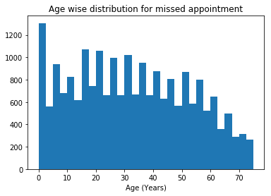

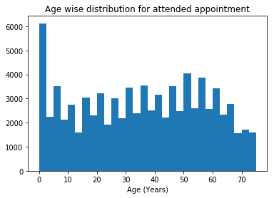

```python
## Generating graph for the Age vs appointment histogram distrbution

## Generating histogram for missed appointment

plot_histogram(appointment_missed,'missed appointment')

## Generating histogram for attended appointment

plot_histogram(appointment_attended,'attended appointment')
```

### Infrence derived from the results of the above analysis are

- From the mean Score we can derive this that patients around **the age of 34-35 years miss the appointment generally while patients of age 38-39 attend the appointments generally**
- Based on the histogram we can conclude **(leaving the 0-2 range) that patients in the age range of 0-33 miss apointment more often than those in the age range of 35-100**
- Probable reason could be that **older people get disease easily as compared to younger ones**
- May be patients **above age of 35 have dependent family so they are more concerned about health**